# Proje Rapor : Özge Ünal 210401117

## Q1: Proje Tanımı

Şirketimiz *Turkuaz* kitap mağazasıdır.Kitap mağazamızın satış rakamları düşüştedir bu sebepten popüler, satış yapma olasılığı yüksek kitapları satması gerekmektedir.

## Q2: Proje Amacı

Bu projede, bir kitap mağazasının satış performansını artırmak amacıyla veri odaklı bir strateji geliştirmek için [Goodreads](https://www.kaggle.com/datasets/jealousleopard/goodreadsbooks) veri setini analiz edeceğim. Bu analizde, kitapların değerlendirilme sayıları, ortalama puanları, yorum sayıları gibi faktörleri inceleyerek, hangi kitapların daha popüler olduğunu ve daha fazla satıldığını belirlemeyi hedefliyorum.

Datasetindeki average_rating, ratings_count, text_reviews_count sütunları kullanılarak;

1. average_rating değeri 3.93’den büyük
2. ratings_count değeri 17.9k büyük
3. text_reviews_count 542’den büyük olan kitaplar satış olasılığı yüksek olarak belirlenecektir.

## Q3: Veri Seti Keşifsel Analizi

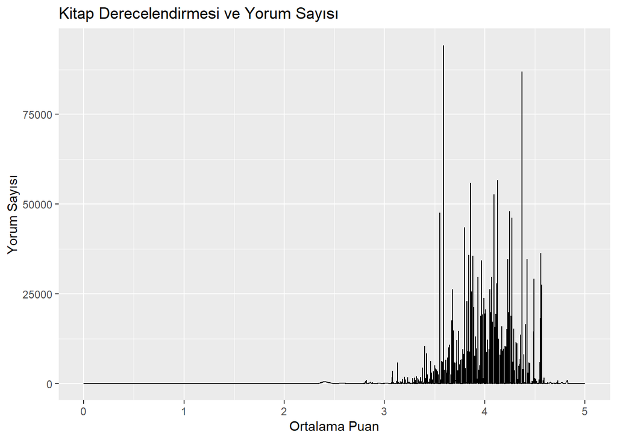

- Bu tablodan şu sonuçları çıkarabiliriz:

*Ortalama Değerlendirme Sayısı:* Kitapların ortalama olarak kaç kez değerlendirildiğini gösterir. Bu, kitapların popülaritesi veya ilgi gördüğü düzey hakkında bir fikir verir.

*Ortalama Puan:* Kitapların ortalama derecelendirmesi. Bu, kitapların genel kalitesi veya okuyucuların kitaplar hakkındaki görüşleri hakkında bir fikir verebilir.

*Toplam Kitap Sayısı:* Veri setindeki toplam kitap sayısı. Bu, analizde kullanılan veri setinin boyutu hakkında bilgi verir.

Bu bölümde veri setinin keşfi ve analizi yapılırken şu bilgileri içerecek şekilde bir yaklaşım benimsenebilir:

- **Veri Setinin Toplanma Süreci:**

[Goodreads](https://www.kaggle.com/datasets/jealousleopard/goodreadsbooks) web sitesinden alınan bir veri seti olduğunu belirtebiliriz ve readr::read_csv() fonksiyonu kullanılarak **spec_tbl_df** tipinde bir değişkene ithal edilmiştir.Veri boyutları aşağıdaki gibidir:

- Satir sayisi : 11127
- Sütun sayisi : 12

| Ortalama Değerlendirme Sayısı | Ortalama Puan | Toplam Kitap Sayısı |
| --- | --- | --- |
| 17936.49 | 3.934075 | 11127 |

- **Önemli Satırlar ve Sütunlar:**

`average_rating`: Kitabın aldığı ortalama puan ne kadar başarılı-başarısız olduğunu gösterir.  
`ratings_count`: İnceleme sayısı ne kadar popüler olduğunu gösterir.  
`text_reviews_count`: Yorum sayısı (text_reviews_count) kitabın ne kadar tartışıldığını, hakkında konuşulduğunu gösterebilir.

Bu sütunlar veri analizi ve modellememiz için önemlidir. Örneğin, kitapların ortalama derecesi ve derece sayısı gibi özellikler, kitapların popülerliğini tahmin etmek için kullanılabilecek özelliklerdir. Yorum sayısı da kitabın etkileşim düzeyini belirlemede kullanılabilir.

- **Veri Tipleri:**

```
##      bookID         title             authors          average_rating
##  Min.   :    1   Length:11127       Length:11127       Min.   :0.000
##  1st Qu.:10287   Class :character   Class :character   1st Qu.:3.770
##  Median :20287   Mode  :character   Mode  :character   Median :3.960
##  Mean   :21311                                         Mean   :3.934
##  3rd Qu.:32105                                         3rd Qu.:4.140
##  Max.   :45641                                         Max.   :5.000
##                                                        NA's   :4
##      isbn              isbn13          language_code        num_pages
##  Length:11127       Length:11127       Length:11127       Min.   :   0.0
##  Class :character   Class :character   Class :character   1st Qu.: 192.0
##  Mode  :character   Mode  :character   Mode  :character   Median : 299.0
##                                                           Mean   : 336.4
##                                                           3rd Qu.: 416.0
##                                                           Max.   :6576.0
##                                                           NA's   :4
##  ratings_count     text_reviews_count publication_date    publisher
##  Min.   :      0   Min.   :    0.0    Length:11127       Length:11127
##  1st Qu.:    104   1st Qu.:    9.0    Class :character   Class :character
##  Median :    745   Median :   47.0    Mode  :character   Mode  :character
##  Mean   :  17936   Mean   :  541.9
##  3rd Qu.:   4994   3rd Qu.:  237.5
##  Max.   :4597666   Max.   :94265.0
##
```

- **Eksikler:**

Kitap basım sayısı ve kitap türü sütunları eksik gösterilebilir. Örneğin, kitabın basım sayısı, kitabın ne kadar popüler olduğunu veya ne kadar çok satıldığını gösterirken, kitap türü ise kitabın içeriği ve hedef kitlesi hakkında bilgi verirdi. Bu bilgileri analiz ederek, hangi tür kitapların daha çok satıldığını veya hangi türlerin daha popüler olduğunu belirleyebilir ve bu bilgilere dayanarak gelecekteki kitap satışları veya pazarlama stratejileri için değerli içgörüler elde edebilirdik.